# Project Proposal: Human Trafficking

5/21/2018

## Human Trafficking (Compressed)

> Recruitment, transportation, transfer, harbouring *of individuals by* means of the threat or use of force or other forms of coercion *for the* purpose of exploitation (sexual exploitation, forced labour or services, slavery or practices similar to slavery or the removal of organs).

> Annex II, Article 3 of the United Nations Convention Against Transnational Organized Crime and Protocols Thereto

## Motivation

- Human Interest
  - robs individuals of freedom and dignity
  - damages families
  - undermines rule of law
  - has been linked with other types of trans-national crime

## Motivation and Background (Statistical Side)

- Generally hard to get individual level data from around the globe on this subject
  - Difficulty recording individuals
  - Different countries = different definitions, gathering, etc
- Hard to get good estimates on true size of problem
  - Media, NGOs, and Governments can sensationalize and misrepresent it
- Hard to really understand risk factors

## Data

[figure not shown]

(Counter-Trafficking Data Collaborative)

[figure not shown]

- > 47,000 individual observations
- 58 features recorded for each individual

## Data

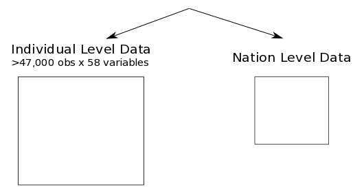

- UN
- US State Department
- World Bank
- World Economic Forum
- Institute for Economics and Peace

## Data

[figure not shown]

- Demographics (age, sex, etc)
- Origin and Host Country
- Type of Labor
- Type of Forced Activities
- Means of Control
- Relationship With Recruiter
- Poverty Level
- GDP per capita
- State Department Ranking
- Crime & Peace Indices
- Immigration Between Countries

## Questions of Interest

- How does means of control relate to type of exploitation and type of labor (while taking into account recruiter relationship and demographics)?
- How do attributes of those trafficked (minor/adult, gender) and the type of exploitation (Sexual vs Labor) relate to country attributes?
  - **State Department:** interested in Organized Crime and Migration Patterns
  - **Academics:** analysis strength of State Department's Tier Metrics

## Structural Problems that will Need Addressing

- Imputation of missing data in individual data
- Smoothing of time attributes for national level trends when attributes are missing

## Reach Goals (Potential Questions of Interest)

- if we obtain duration of captivity data: how does change in country's attributes over time change characteristics of individuals enslaved?
- Network analysis between host and origin countries